# DC Address Analysis

Author

Ian Milko

Published

December 22, 2024

Modified

May 20, 2026

A project to explore how addresses in Washington D.C. fit within the unique street naming structure. Several streets in Washington are named after the various U.S. states. Additionally, downtown Washington has a very intuitive and structured grid system, with east-west streets being assigned a letter, and north-south streets assigned a number, both corresponding to how far they are from the Capitol. I have called these Standard Named Streets (SNS).

SNS streets are named in ascending order starting from the Capitol, so “5th St” is five streets closer to the Capitol than “10th St”, and same for “E St” and “J St”<sup>[note 1]</sup>. Naturally, this means that there are two of each street: each lettered street north of the Capitol has a twin south of the Capitol, and each numbered street to the east has a twin to the west. This presents a problem: there are four of each intersection (e.g. four different instances of “22nd St and H St”), and if the addresses for buildings correspond to what block they are on, which they do (e.g. “410 G St” is on G street between 4th St and 5th St, also known as the “400 block of G St”), then there are **four** different buildings with the same address. To solve this, the whole district is split into four quadrants with the origin on the Capitol: northwest, northeast, southwest, and southeast. The quadrant is appended to the street name (e.g. “410 G St NE” is in the northeast quadrant on G St NE, between 4th St NE and 5th St NE). This is the general idea, but as the saying goes, “No plan survives contact with the enemy”, and in this case, the enemy is humanity’s eternal foe: reality. There are several delightful exceptions to this system, and finding them is like a treasure hunt.

> Note 1: There is actually no “J St” in the district, either north or south. The reason for this has never been conclusively determined, but the strongest explanation is that when the city was planned in the 1790s, the letters “I” and “J” were visually very similar, so one of them had to be ommitted to prevent confusion. There are also no “X”, “Y”, or “Z” streets. “B St” exists only east of the Anacostia river, and only in the southeastern quadrant. West of the Anacostia river, Constitution Ave and Independance Ave occupy the place where B St would have been, and A St exists only east of the Capitol due to the National Mall, which renamed both A St locations to Madison Dr NW and Jefferson Dr SW. However, there *is* a “Jay St NE” in the Deanwood neighborhood, which is an example of a phenomenon where streets outside the original grid often have names in alphabetical order. There are many more exceptions to the grid, including my personal favorite: 13 1/2 St NW, next to the mayor’s office.

> Note 2: There is a system to which side of the street contains odd or even address numbers. This can be confusing without the context, so I will show my process of discovery. First, we pick out a random block, such as our previous 400 block of G St NE, and observe that even numbers are on the north side, and odd numbers are on the south side. We might first think that odd and even numbers follow a similar principle to street names; that is, they are determined in relation to the Capitol. This would be consistent with the rest of the planning philosophy, but after a few seconds of thought, this theory doesn’t make much sense because we subconsciously know that humans prefer even numbers to odd numbers (and even if we didn’t know this, there is a considerable body of science that supports this idea), and why would the preferred option be farther from the Capitol? Further, we check the same block but in the *southeast* quadrant and we discover that it also has even numbers to the north and odd numbers to the south. Ok, so maybe even numbers are on the north side and odd numbers are on the south side because for some reason north is preferrable to south (this preference is best exemplified by the Mercator projection of the globe). This seems reasonable enough, but just to be sure, let’s go west to the 400 block of G St SW. To our dismay, the north side of the street now contains odd numbers, and the south side contains even numbers! Since we have to be thorough, we check the 400 block of G St NW and find the same thing: odds to the north, evens to the south. At this point, we physically throw our hands in the air and let out an expletive, because what kind of insane system would have even numbers to the north in the east quadrants and to the south in west quadrants? With terror in our hearts, we investigate the vertical axis. The 700 block of 4th St NE lies between G and H Streets NE (G is the seventh letter of the alphabet), and it has even numbers to the west and odd numbers to the east. The same block number in the southeast quadrant has, horrifyingly yet predictably, odd numbers to the west and even numbers to the east. Checking the western quadrants, our worst fears are confirmed: for vertical streets in the northern quadrants, evens are to the west and odds are to the east, and in southern quadrants they are flipped. Now we try to come up with a reason for what could have inspired this god-forsaken schema: maybe Pierre L’Enfant secretly hated postal workers, maybe he was a sort of geometry nerd and there is some way where the quadrant gets rotated for some obscure reason, maybe it was done as a way for residents to be able to know which quadrant they were in based on the unique organization of odd and even house numbers. Grasping desperately at any straw in the vicinity, we just can’t take it any longer, and admit defeat by turning to Google. It turns out, there *is* a logical system and when we finish reading the explanation, the only words we can muster are “because of course it is”: When standing in a street and facing away from the Capitol, even numbers are assigned to a person’s left, and odd numbers are assigned to the person’s right. Because in English, we read left to right, thereby associating left as “first” and therefore preferrable, as are even numbers. So ends our journey.

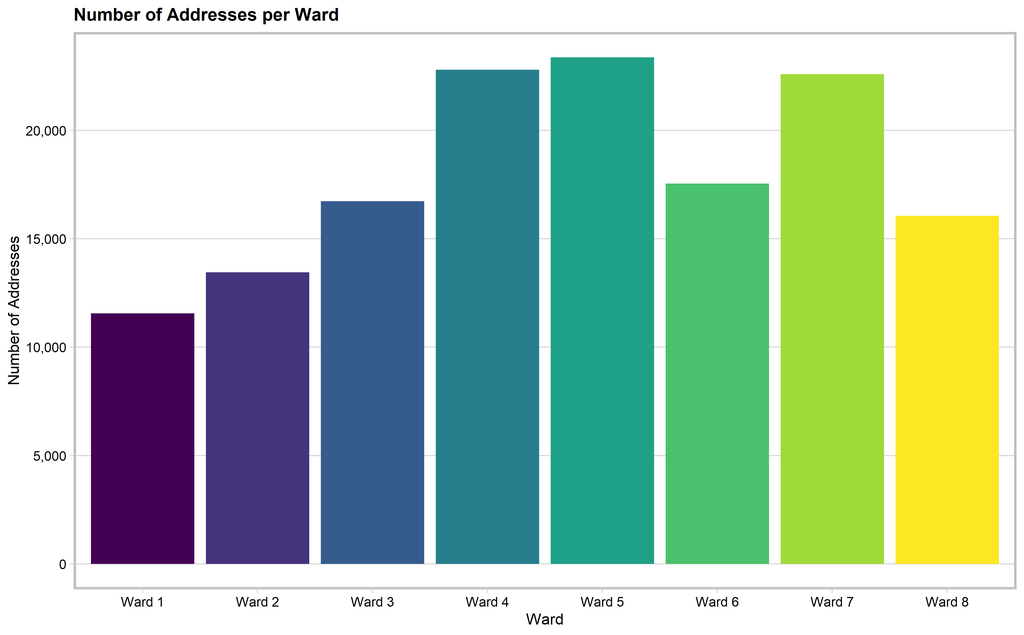

```r
per_ward_col <- addrs %>%
    clean_names() %>%
    filter(quadrant != "BN") %>%
    count(ward) %>%
    ggplot() +
        geom_col(
            aes(x = ward, y = n, fill = ward)
        ) +
        scale_fill_viridis_d() +
        scale_y_continuous(labels = comma) +
        theme_minimal_hgrid() +
        labs(
            x = "Ward",
            y = "Number of Addresses",
            title = "Number of Addresses per Ward"
            ) +
        theme(legend.position = 'none',
            panel.border = element_rect(
                linetype = 'solid',
                color = 'grey75',
                linewidth = 2,
                fill = NA
            )
        )
per_ward_col
```

Note that the plot below is **not** a density plot. It simply shows the total number of addresses in each ward. The smaller Ward 1 has fewer addresses than the larger Ward 5.

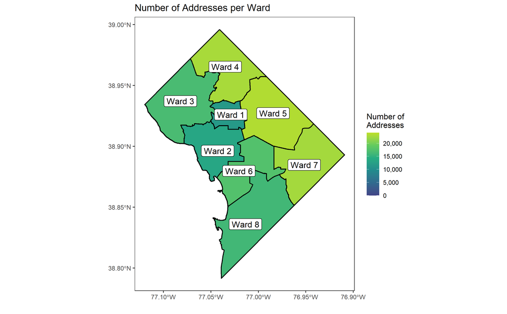

```r
ward_data <- addrs %>%
    clean_names() %>%
    mutate(ward_name = ward) %>%
    filter(quadrant != "BN") %>%
    count(ward_name)

wards <- read_sf('Wards_from_2022/Wards_from_2022.shp') %>%
    clean_names() %>%
    mutate(ward_name = name) %>%
    mutate(area = st_area(.)) %>%
    left_join(ward_data, by = 'ward_name')

per_ward_map <- ggplot(data = wards) +
    geom_sf(aes(fill = n), color = 'black', linewidth = 0.6) +
    geom_sf_label(aes(label = ward_name), size = 4) +
    scale_fill_viridis_c(begin = 0.2, end = 0.9, option = "D", direction = 1, labels = comma) +
    expand_limits(fill = seq(0, 24000)) +
    labs(
        x = "",
        y = "",
        title = "Number of Addresses per Ward",
        fill = "Number of\nAddresses"
        ) +
    theme_bw() +
    theme(panel.grid.major = element_blank())
per_ward_map
```

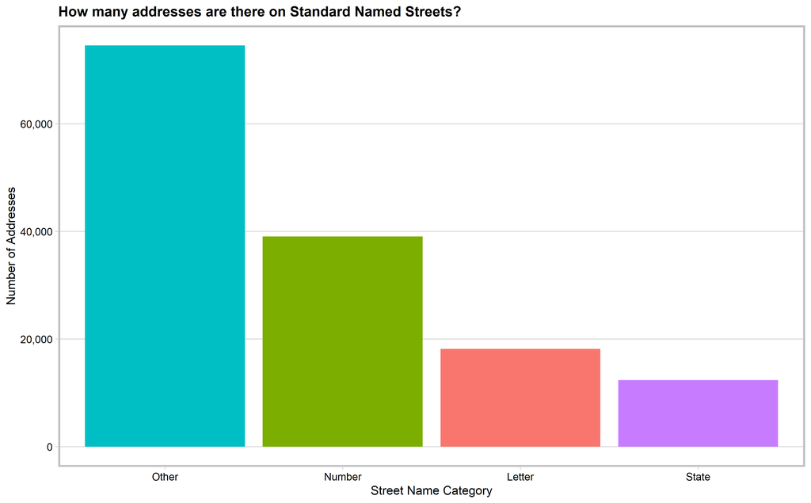

```r
addrs_plot <- addrs %>%
    count(st_name_cat) %>%
    ggplot() +
    geom_col(
        aes(x = reorder(st_name_cat, n, decreasing=TRUE), y = n, fill=st_name_cat),
    ) +
    scale_y_continuous(labels = comma) +
    labs(
        x = 'Street Name Category',
        y = 'Number of Addresses',
        title = 'How many addresses are there on Standard Named Streets?'
    ) +
    theme_minimal_hgrid() +
    theme(legend.position = 'none',
        panel.border = element_rect(
            linetype = 'solid',
            color = 'grey75',
            linewidth = 2,
            fill = NA
        )
    )
addrs_plot
```

The plot below illustrates the ratio of SNS addresses to total addresses in a given ward. We can see that Ward 6, which includes Capitol Hill, Southwest Waterfront, and the Union Station/NoMa area north of the Capitol, has a high ratio of SNS addresses due to the grid being largely intact in most of the ward. In comparison, the neighboring Ward 8 has a much lower SNS ratio, due to it being home to southeast DC and Joint Base Anacostia.

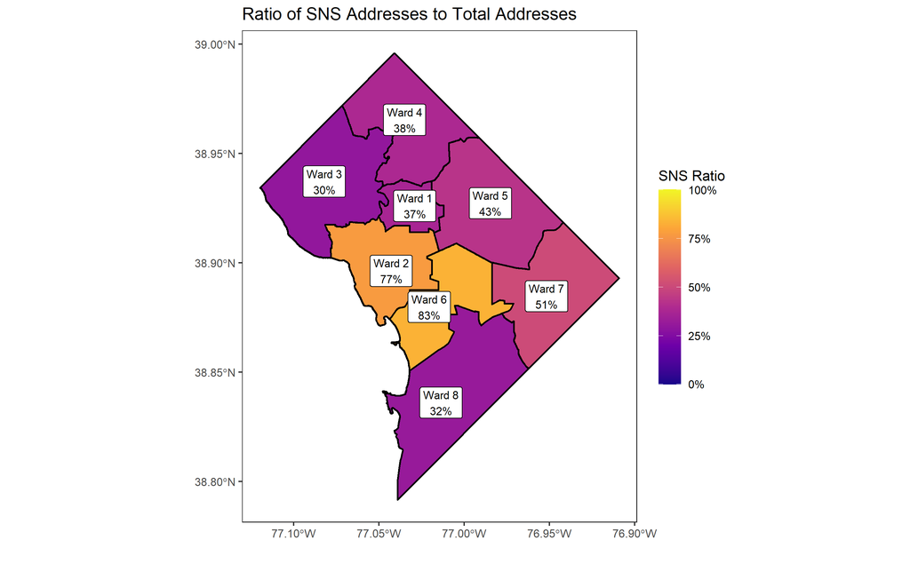

```r
ward_addrs <- addrs %>%
    clean_names() %>%
    mutate(ward_name = ward) %>%
    filter(quadrant != "BN")

sns_wards <- ward_addrs %>%
    filter(st_name_cat != "Other") %>%
    group_by(ward_name) %>%
    summarize(sns_addrs = n())

tot_addrs_wards <- ward_addrs %>%
    group_by(ward_name) %>%
    summarize(tot_addrs = n())

ward_addrs_stats <- tot_addrs_wards %>%
    left_join(sns_wards, by = 'ward_name') %>%
    mutate(sns_ratio = sns_addrs / tot_addrs)

ward_geo <- wards %>%
    left_join(ward_addrs_stats, by = 'ward_name')

sns_map <- ggplot(data = ward_geo) +
    geom_sf(aes(fill = sns_ratio), color = 'black', linewidth = 0.6) +
    geom_sf_label(aes(label = paste0(ward_name, "\n", round(sns_ratio, 2) * 100, "%")), size = 3) +
    scale_fill_viridis_c(begin = 0.01, end = 0.99, option = "C", direction = 1, labels = label_percent()) +
    expand_limits(fill = seq(0, 1, by = 0.1)) +
    labs(
        x = "",
        y = "",
        title = "Ratio of SNS Addresses to Total Addresses",
        fill = "SNS Ratio"
        ) +
    theme_bw() +
    theme(panel.grid.major = element_blank(),
        legend.key.height = unit(30, "pt")
    )
sns_map
```